# Single-Cell Omics Research and Education

SCORE #3: Reporting Data

Jonathan Nelson and Jessica Bahena-Lopez

31 March 2025

```r
library("dplyr")
library("Seurat")
library("knitr")
library("ggplot2")
library("BiocManager")
library("here")
#BiocManager::install("EnhancedVolcano")
library("EnhancedVolcano") #volcano plot
#install.packages('DESeq2') #for DEG
library("DESeq2")
library("tidyverse") #tidy up data
library("styler") #tidy up data


if (!require("kableExtra")) {install.packages("kableExtra"); require("kableExtra")} # for color brewer
if (!require("RColorBrewer")) {install.packages("RColorBrewer"); require("RColorBrewer")} # for color brewer
if (!require("sctransform")) {install.packages("sctransform"); require("sctransform")} # for data normalization
if (!require("glmGamPoi")) {BiocManager::install('glmGamPoi'); require("glmGamPoi")} # for data normalization, sctransform
if (!require("cowplot")) {install.packages("cowplot"); require("cowplot")} # for figure layout
if (!require("patchwork")) {install.packages("patchwork"); require("patchwork")} # for figure patching
if (!require("openxlsx")) {install.packages("openxlsx"); require("openxlsx")} # to save .xlsx files

# install.packages("styler")



set.seed(12345)
# here()
```

# 1 Welcome

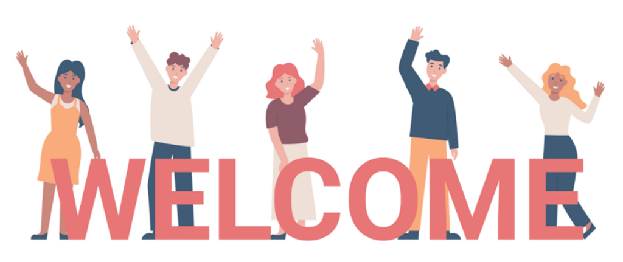

Welcome to the **Single-Cell Omics Research and Education Club**!

If this is your time to the club, **I want to extend and extra-special welcome to you!**

I’m **Jonathan Nelson**, an Assistant Professor at the University of Southern California. I’m a **wet** scientist turned **wet+dry** scientist. I’ve been working with **single-cell RNAseq data** for the past **5 years** and I’m excited to share what I’ve learned with you.

## 1.1 SCORE Values

### 1.1.1 **Learning**

We believe that bioinformatics is a constantly evolving field, and that ongoing learning and professional development is essential to staying up-to-date. We encourage members to share their knowledge and experiences with each other, and to seek out opportunities for continued learning.

### 1.1.2 **Accessibility**

We believe that access to bioinformatics support should be available to everyone. We strive to create a welcoming and inclusive environment where all members can feel comfortable asking for help and contributing to the group.

### 1.1.3 **Collaboration**

We believe that working together is key to achieving success in bioinformatics. We value the diversity of perspectives and backgrounds that each member brings, and we encourage open communication and the sharing of ideas.

### 1.1.4 **Integrity**

We believe in conducting ourselves with honesty and professionalism in all our interactions. We hold ourselves to high ethical standards and respect the privacy and confidentiality of all members.

### 1.1.5 **Empathy**

We believe in approaching each other with empathy and kindness. We understand that bioinformatics can be a challenging and sometimes frustrating field, and we strive to support each other through these difficulties.

## 1.2 Context and Expectations

I know a lot of this has been going on in the background for everyeone and I wanted to bring it to the forefront. **My expectation** is that we have **about 6 of these meetings** together and then we can re-evaluate if we want to continue as a group or not.

Today’s code (**this html file**) will be posted to the SCORE website (https://usckrc.github.io/website/score.html)

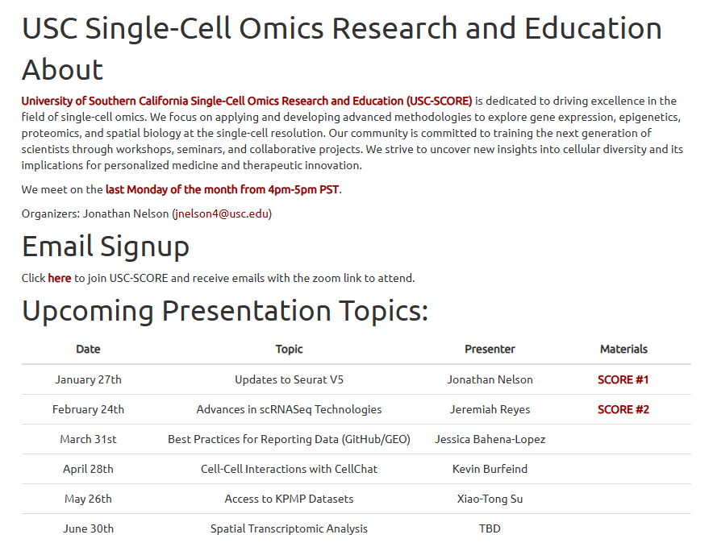

# 2 The Agenda!

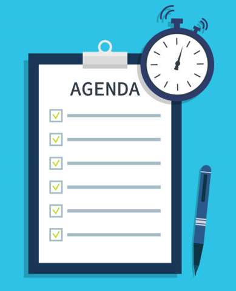

## 2.1 Music and Memes

## 2.2 Coding Crumbs: **R styling**

## 2.3 Recreating a Figure: **Gantt Chart**

## 2.4 Main Theme: **Best Practices for Reporting Data**

# 3 Music and Memes

## 3.1 This Months Coding Music

**LAUREL**: Life Worth Living

https://open.spotify.com/track/1mCvM05OlYWQd77RDxCTLD?si=7d8beb22c2274997

[figure not shown]

## 3.2 The Memes!

[figure not shown]

# 4 Coding Crumbs: **R styling**

[figure not shown]

## 4.1 And I **LOVE** clean code

## 4.2 Confession: **I write ugly code**

## 4.3 There is **Help**

## 4.4 Clean legible code is important for reproducibility

### 4.4.1 Hadley Wickham’s Style Guide

http://adv-r.had.co.nz/Style.html

### 4.4.2 Option 1: **Native R**

### 4.4.3 Code > Reformat Code (**Ctrl+Shift+A**)

#### 4.4.3.1 Before

[figure not shown]

#### 4.4.3.2 After

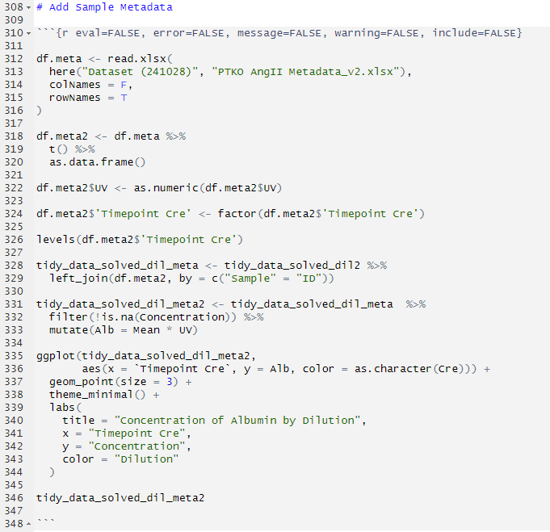

### 4.4.4 Option 2: **Styler Package**

[figure not shown]

https://github.com/r-lib/styler?tab=readme-ov-file

install.packages(“styler”)

https://www.youtube.com/watch?app=desktop&v=yUA3NpJLH6I&t=220s&t=156

#### 4.4.4.1 Before

#### 4.4.4.2 After

[figure not shown]

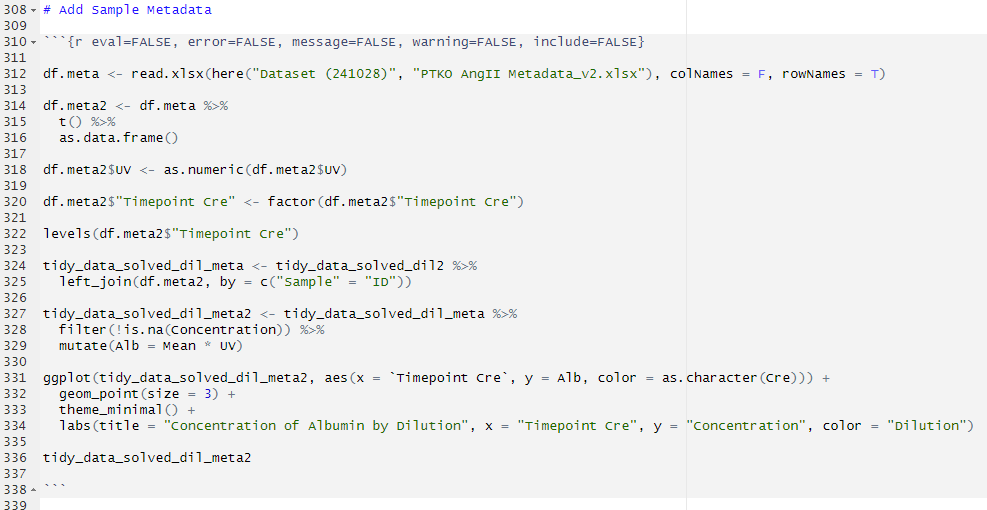

### 4.4.5 Option 3: **ChatGPT**

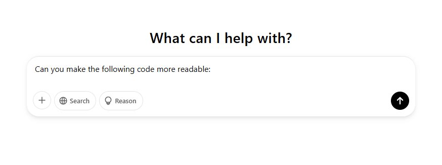

#### 4.4.5.1 Before

##### 4.4.5.1.1 After

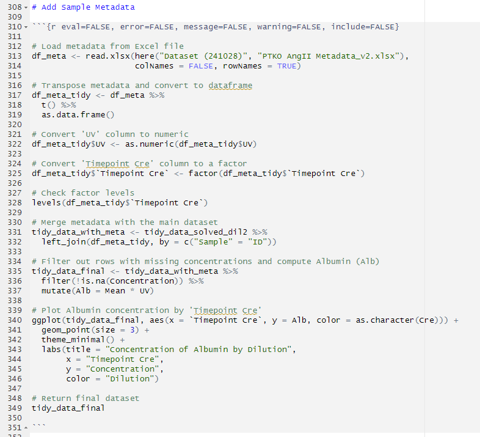

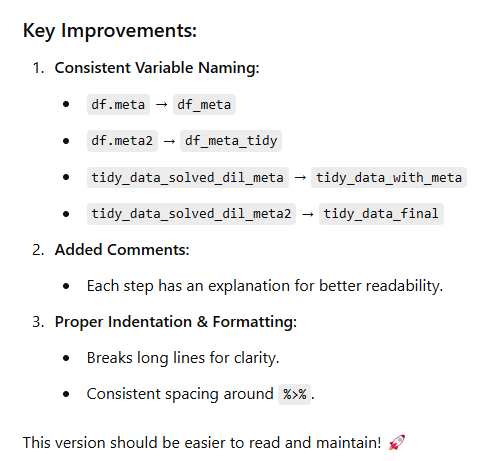

## 4.5 **Take Home**

### 4.5.1 **Styling** your code is important

### 4.5.2 But spend your time **thinking about the logic** of your code

### 4.5.3 **Styler** is a great tool to help with minimal effort

### 4.5.4 **ChatGPT** is also a great tool to help

### 4.5.5 I’m going to try to run my code through **chatGPT** before publishing it

# 5 Recreating a Figure: **Gantt Chart**

[figure not shown]

## 5.1 Final Product!

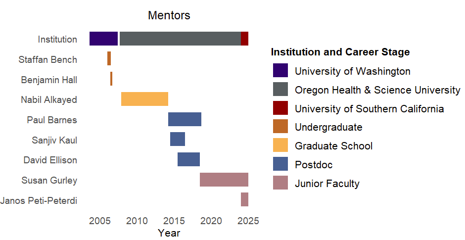

## 5.2 History

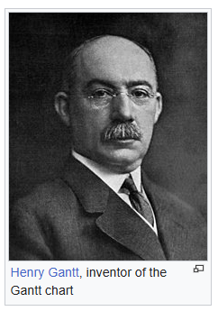

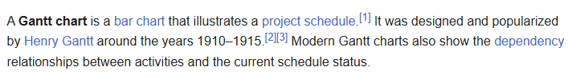

https://en.wikipedia.org/wiki/Gantt_chart

## 5.3 Great for Project Management

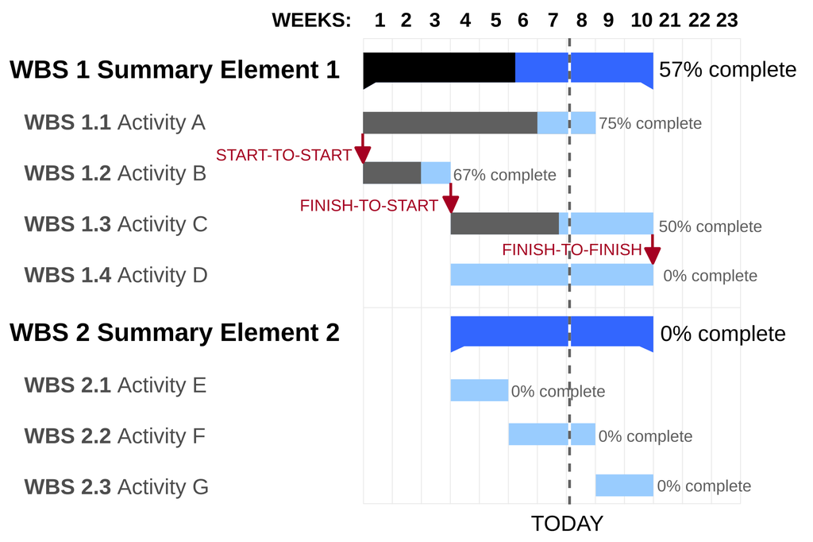

## 5.4 ggplot2 Lessons for Me

### 5.4.1 **Layering** a graph with two different dataframes

### 5.4.2 **Leveling** a graph with data from two different dataframes

### 5.4.3 **Setting** a color palette

## 5.5 Starting Place

I wanted to **start with one csv file** that was flexible to fill out.

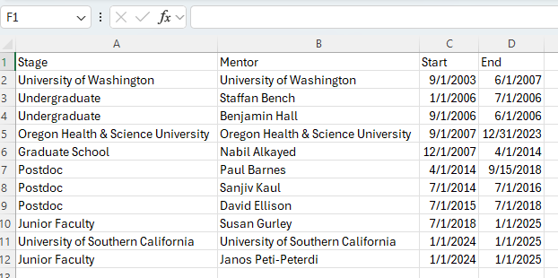

## 5.6 Load Data, Define Institutes vs. Individuals, and Pivot Longer

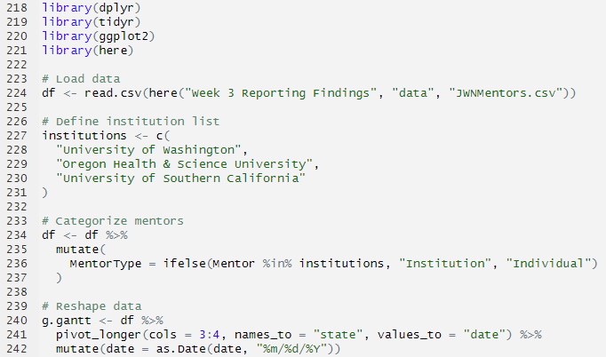

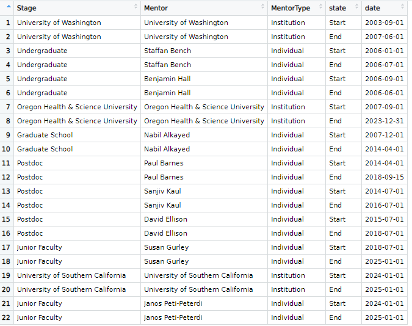

## 5.7 Create Institutions Dataframe, Define the Order of Graph + Legend, and Set the Color Palette

### 5.7.1 **Note:** Set the **same factor** on two different dataframes

### 5.7.2 **Note:** I asked **ChatGPT** to help me select the color palette

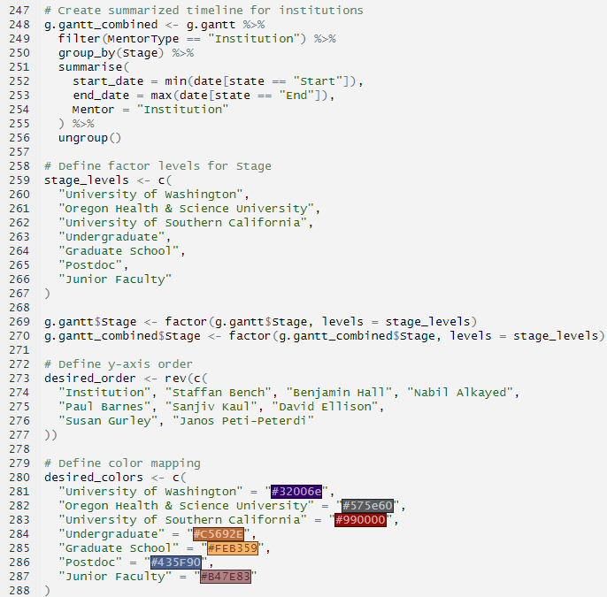

## 5.8 ggplot2 code

### 5.8.1 **Note:** geom_segment() **AND** geom_line()

### 5.8.2 **Note:** labs(color = ““) sets the legend title

### 5.8.3 **Note:** scale_y_discrete() sets the order of mentors

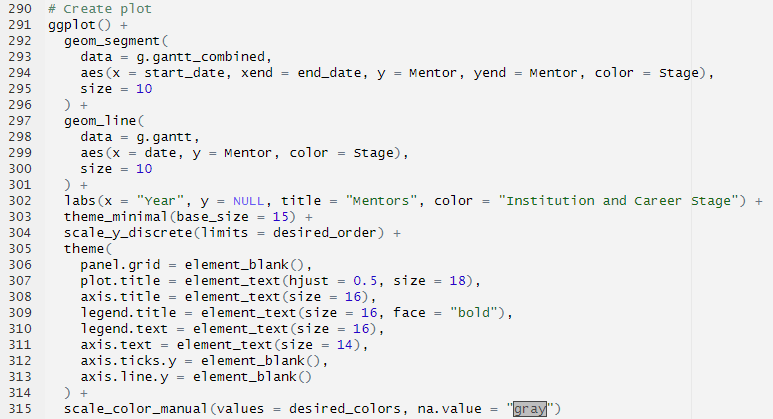

## 5.9 **Code** to produce the **Gantt chart**

### 5.9.1 Yes, **I asked chatGPT** to clean up and annotate the code!

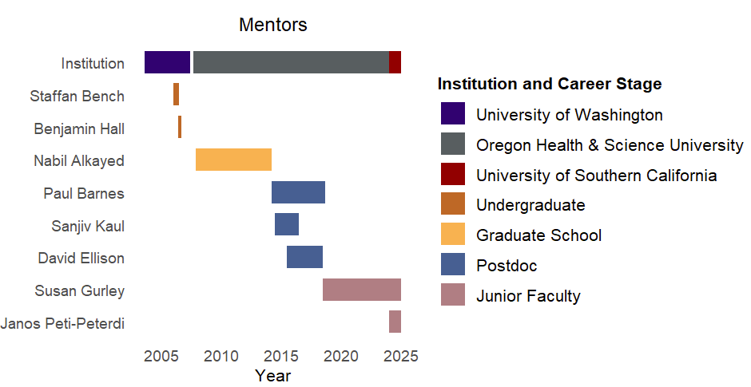

```r
library(dplyr)
library(tidyr)
library(ggplot2)
library(here)

# Load data
df <- read.csv(here("Week 3 Reporting Findings", "data", "JWNMentors.csv"))

# Define institution list
institutions <- c(
  "University of Washington",
  "Oregon Health & Science University",
  "University of Southern California"
)

# Categorize mentors
df <- df %>%
  mutate(
    MentorType = ifelse(Mentor %in% institutions, "Institution", "Individual")
  )

# Reshape data
g.gantt <- df %>%
  pivot_longer(cols = 3:4, names_to = "state", values_to = "date") %>%
  mutate(date = as.Date(date, "%m/%d/%Y"))

# Create summarized timeline for institutions
g.gantt_combined <- g.gantt %>%
  filter(MentorType == "Institution") %>%
  group_by(Stage) %>%
  summarise(
    start_date = min(date[state == "Start"]),
    end_date = max(date[state == "End"]),
    Mentor = "Institution"
  ) %>%
  ungroup()

# Define factor levels for Stage
stage_levels <- c(
  "University of Washington",
  "Oregon Health & Science University",
  "University of Southern California",
  "Undergraduate",
  "Graduate School",
  "Postdoc",
  "Junior Faculty"
)

g.gantt$Stage <- factor(g.gantt$Stage, levels = stage_levels)
g.gantt_combined$Stage <- factor(g.gantt_combined$Stage, levels = stage_levels)

# Define y-axis order
desired_order <- rev(c(
  "Institution", "Staffan Bench", "Benjamin Hall", "Nabil Alkayed",
  "Paul Barnes", "Sanjiv Kaul", "David Ellison",
  "Susan Gurley", "Janos Peti-Peterdi"
))

# Define color mapping
desired_colors <- c(
  "University of Washington" = "#32006e",
  "Oregon Health & Science University" = "#575e60",
  "University of Southern California" = "#990000",
  "Undergraduate" = "#C5692E",
  "Graduate School" = "#FEB359",
  "Postdoc" = "#435F90",
  "Junior Faculty" = "#B47E83"
)

# Create plot
ggplot() +
  geom_segment(
    data = g.gantt_combined,
    aes(x = start_date, xend = end_date, y = Mentor, yend = Mentor, color = Stage),
    size = 10
  ) +
  geom_line(
    data = g.gantt,
    aes(x = date, y = Mentor, color = Stage),
    size = 10
  ) +
  labs(x = "Year", y = NULL, title = "Mentors", color = "Institution and Career Stage") +
  theme_minimal(base_size = 15) +
  scale_y_discrete(limits = desired_order) +
  theme(
    panel.grid = element_blank(),
    plot.title = element_text(hjust = 0.5, size = 18),
    axis.title = element_text(size = 16),
    legend.title = element_text(size = 16, face = "bold"),
    legend.text = element_text(size = 16),
    axis.text = element_text(size = 14),
    axis.ticks.y = element_blank(),
    axis.line.y = element_blank()
  ) +
  scale_color_manual(values = desired_colors, na.value = "gray")
```

# 6 Main Theme: **Reporting Data**

## 6.1 Best Practices for Reporting Data for Manuscripts

[figure not shown]

## 6.2 Pipeline

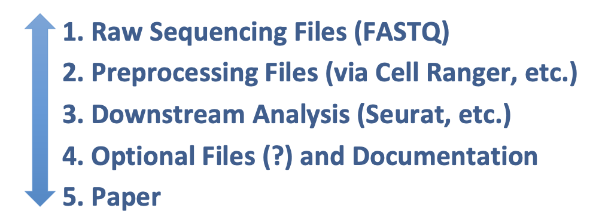

### 6.2.1 Raw Sequencing Files (FASTQ)

- Raw output from sequencers (e.g., NovaSeq, NextSeq)
- In sc/snRNA-seq: short reads from cDNA (reverse-transcribed mRNA)

#### 6.2.1.1 Main files

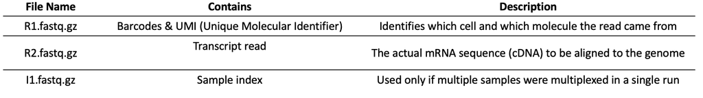

- FASTQ files are large → compressed with `.gz` to save space
- Next: processed by pipelines like Cell Ranger, STARsolo,(bulk RNA-seq) or Kallisto|Bustools (pseudoalignment), etc.

### 6.2.2 Preprocessing Files (via Cell Ranger, etc.)

- FASTQ files → processed with pipelines (e.g., Cell Ranger)
- Tasks: demultiplex barcodes, deduplicate UMIs, align reads, build gene × cell matrix

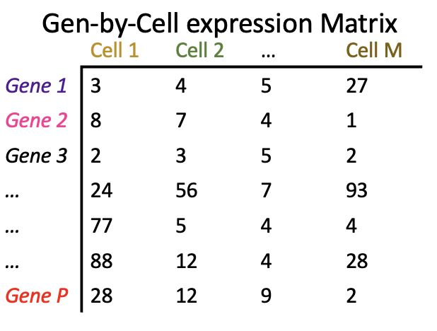